# BIOSTAT 702: Exercise 4.2

Elena Song

2026-10-16

# Question 1

We will be simulating data from a designed experiment, with 100 patients. Patient 1 receives X=1, patient 2 receives X=2, …, patient 100 receives X=100.

### Question 1.1

Simulate a SLR model meeting all its assumptions. The slope should be 0.5, the intercept should be 2, and the errors should be normal with mean 0 and standard deviation 1. Set the seed value for the pseudorandom number generator to 1, so that everyone obtains identical results.

```r
# Set seed for reproducibility
set.seed(1)

# Create X values for 100 patients
X <- 1:100

# Generate random errors
error <- rnorm(100, mean = 0, sd = 1)

# Generate Y values
Y <- 2 + 0.5 * X + error

# Create a data frame
data1 <- data.frame(X, Y)

# Display the first six observations
head(data1)
```

```
##   X        Y
## 1 1 1.873546
## 2 2 3.183643
## 3 3 2.664371
## 4 4 5.595281
## 5 5 4.829508
## 6 6 4.179532
```

### Question 1.2

Create a scatterplot of Y vs X and add the best-fitting regression line to the plot. How good does the fit appear to be?

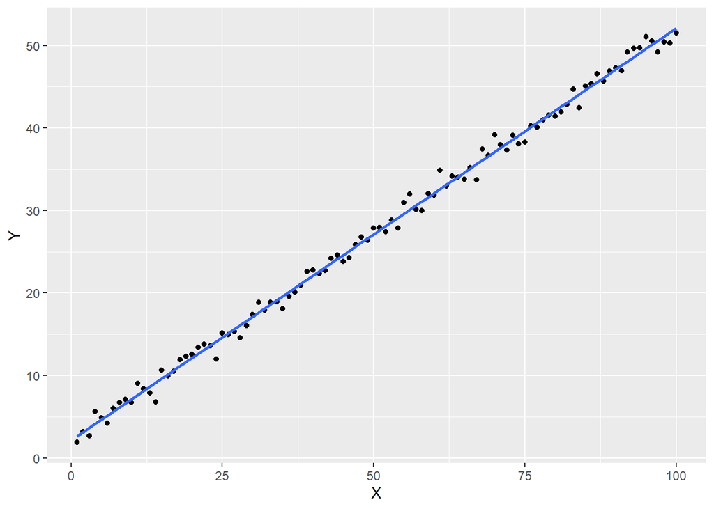

```r
library(ggplot2)
ggplot(data = data1, aes(x = X, y = Y)) +
  geom_point() +
  geom_smooth(method = "lm", se = FALSE)
```

**Answer:** The linear regression model appears to fit the data very well. The points are closely clustered around the fitted regression line, indicating a strong positive linear relationship between X and Y.

### Question 1.3

Create a Q-Q plot to check the normality of the residuals. Do the residuals appear to be normal?

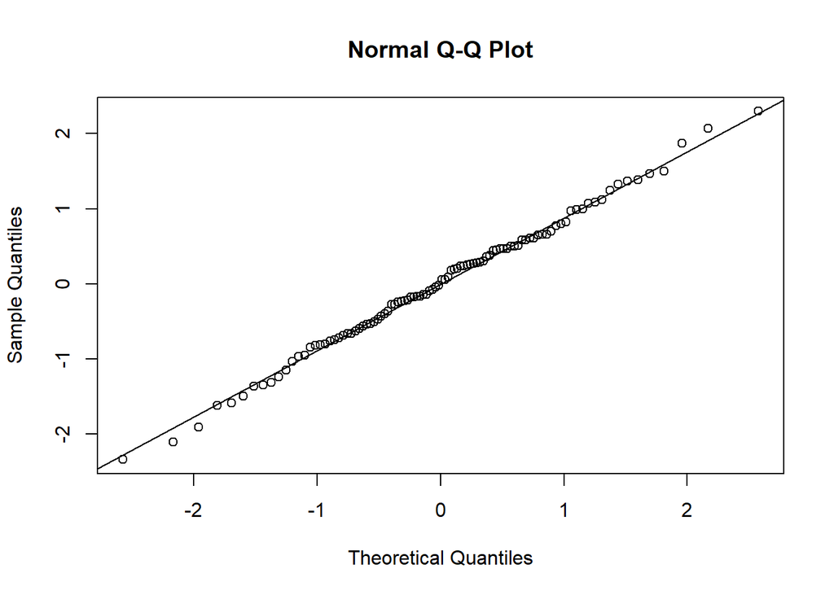

```r
# Fit a simple linear regression model
model1 <- lm(Y ~ X, data = data1)

# Create a Q-Q plot of residuals
qqnorm(residuals(model1))

# Add a reference line
qqline(residuals(model1))
```

**Answer:** The residuals appear to be approximately normally distributed because most points lie close to the reference line in the Q-Q plot, with minor deviations in the tails.

### Question 1.4

Create a residual plot to check the homogeneity of variances assumption. Do the variances look homogeneous?

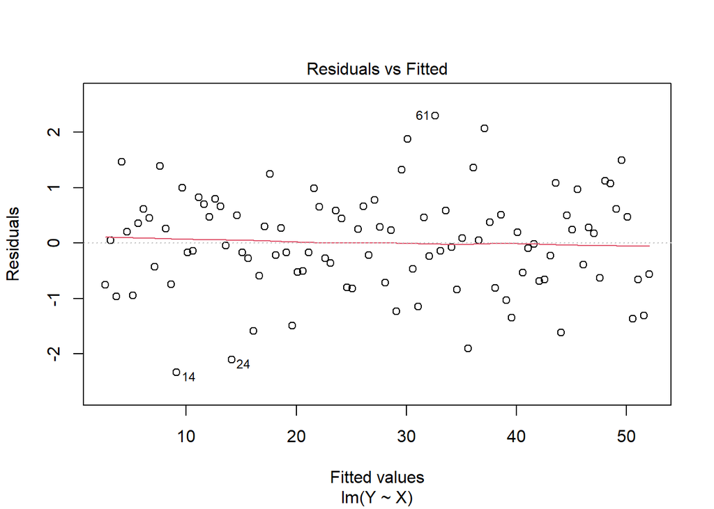

```r
# Create residual plot
plot(model1, which = 1)
```

**Answer:** The residuals appear to have approximately constant variance across the fitted values. They are randomly scattered around zero, with no clear funnel-shaped pattern, suggesting that the homogeneity of variances assumption is reasonable.

### Question 1.5

Fit a SLR model and calculate the R-square statistic. What is it?

```r
# Fit a simple linear regression model
model1 <- lm(Y ~ X, data = data1)

# Display regression results
summary(model1)
```

```
##
## Call:
## lm(formula = Y ~ X, data = data1)
##
## Residuals:
##      Min       1Q   Median       3Q      Max
## -2.34005 -0.60584  0.01551  0.58514  2.29747
##
## Coefficients:
##             Estimate Std. Error t value Pr(>|t|)
## (Intercept) 2.131666   0.181897   11.72   <2e-16 ***
## X           0.499549   0.003127  159.75   <2e-16 ***
## ---
## Signif. codes:  0 '***' 0.001 '**' 0.01 '*' 0.05 '.' 0.1 ' ' 1
##
## Residual standard error: 0.9027 on 98 degrees of freedom
## Multiple R-squared:  0.9962, Adjusted R-squared:  0.9961
## F-statistic: 2.552e+04 on 1 and 98 DF,  p-value: < 2.2e-16
```

```r
# Extract R-squared
summary(model1)$r.squared
```

```
## [1] 0.9961745
```

**Answer:** The R-squared value is 0.9962, indicating approximately 99.62% of the variation in Y is explained by X in the fitted linear regression model. This suggests an excellent fit.

## Question 2

### Question 2.1

Repeat the above analyses (including resetting the seed to 1), but change the standard deviation to 15. What do you find?

Take the scatterplot and add a LOESS function. Visually, how close does the smoothed curve look like a straight line?

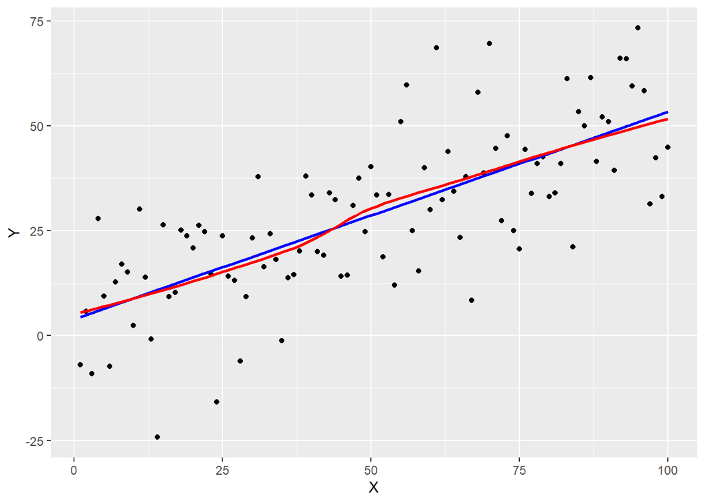

```r
# Set seed
set.seed(1)

# Simulate data with SD = 15
X <- 1:100
error2 <- rnorm(100, mean = 0, sd = 15)
Y2 <- 2 + 0.5 * X + error2

# Create data frame
data2 <- data.frame(X, Y = Y2)

# Fit SLR model
model2 <- lm(Y ~ X, data = data2)

# Scatterplot with regression line and LOESS curve
ggplot(data = data2, aes(x = X, y = Y)) +
  geom_point() +
  geom_smooth(method = "lm", se = FALSE, color = "blue") +
  geom_smooth(method = "loess", se = FALSE, color = "red")
```

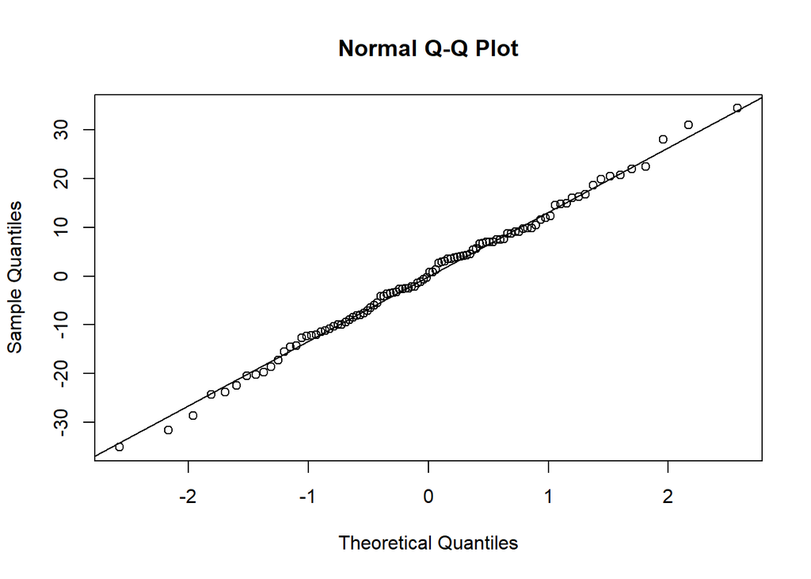

```r
# Q-Q plot of residuals
qqnorm(residuals(model2))
qqline(residuals(model2))
```

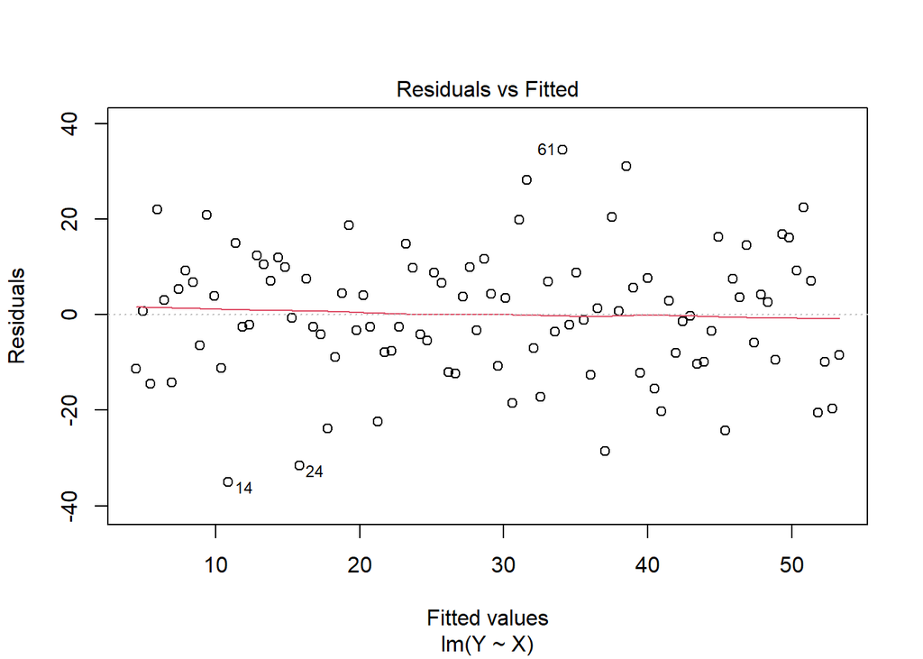

```r
# Residual plot
plot(model2, which = 1)
```

```r
# R-squared
summary(model2)$r.squared
```

```
## [1] 0.5301334
```

**Answer:** When the error standard deviation increased from 1 to 15, the data points became more widely scattered around the regression line. The R-squared decreased from 0.9962 to 0.5301, indicating a weaker fit. However, the Q-Q plot still suggests approximate normality, and the residual plot shows relatively constant variance. The LOESS curve remains close to the fitted regression line, suggesting that a linear model is still appropriate.

### Question 2.2

Repeat the above analysis (including resetting the seed to 1), but change the standard deviation to 100. What do you find?

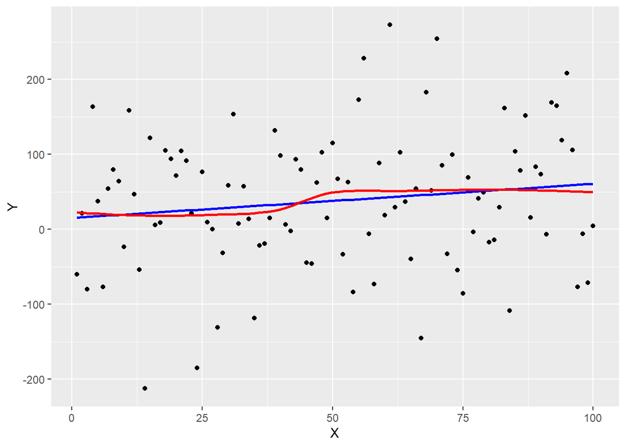

```r
# Set seed
set.seed(1)

# Simulate data with SD = 100
X <- 1:100
error3 <- rnorm(100, mean = 0, sd = 100)
Y3 <- 2 + 0.5 * X + error3

# Create data frame
data3 <- data.frame(X, Y = Y3)

# Fit SLR model
model3 <- lm(Y ~ X, data = data3)

# Scatterplot with regression line and LOESS curve
ggplot(data = data3, aes(x = X, y = Y)) +
  geom_point() +
  geom_smooth(method = "lm", se = FALSE, color = "blue") +
  geom_smooth(method = "loess", se = FALSE, color = "red")
```

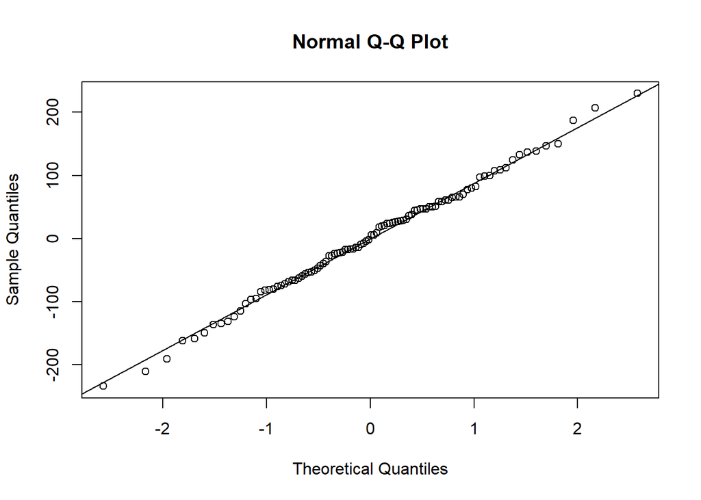

```r
# Q-Q plot
qqnorm(residuals(model3))
qqline(residuals(model3))
```

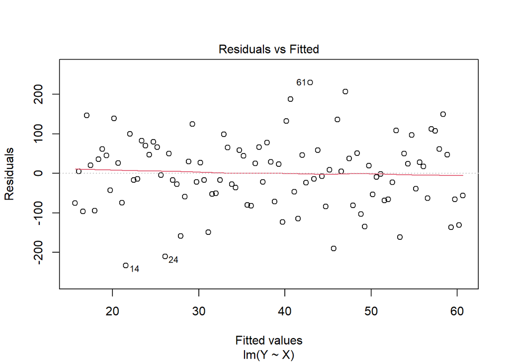

```r
# Residual plot
plot(model3, which = 1)
```

```r
# R-squared
summary(model3)$r.squared
```

```
## [1] 0.02113635
```

**Answer:** When the error standard deviation increases to 100, the data points become much more widely scattered, making the linear relationship difficult to identify visually. The R-squared decreases to 0.0211, indicating that the linear model explains much less of the variation in Y. Although the LOESS curve may deviate from the fitted straight line due to the large amount of noise, the underlying regression relationship remains linear. The Q-Q plot still suggests approximate normality, and the residual plot shows relatively constant variance. This demonstrates that a poor model fit does not necessarily indicate a violation of the regression assumptions.

## Question 3

### Question 3.1

Repeat the above analysis (including resetting the seed to 1), with the regression parameters as before, but change the distribution of the error term to 10*K, where K is a random number derived from a t-distribution with 4 degrees of freedom. Does the scatterplot still look good? What about the Q-Q plot? Specifically, the t-distribution has heavier tails than the normal. How can this be discovered in the Q-Q plot?

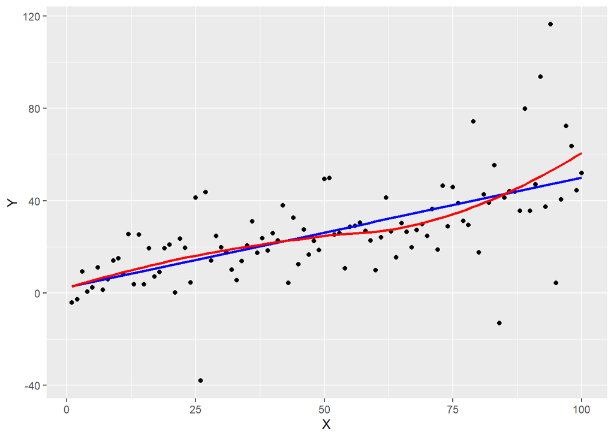

```r
# Set seed
set.seed(1)

# Create X values
X <- 1:100

# Generate errors from a t-distribution with df = 4
error4 <- 10 * rt(100, df = 4)

# Generate Y values
Y4 <- 2 + 0.5 * X + error4

# Create data frame
data4 <- data.frame(X, Y = Y4)

# Fit SLR model
model4 <- lm(Y ~ X, data = data4)

# Scatterplot with regression line and LOESS curve
ggplot(data = data4, aes(x = X, y = Y)) +
  geom_point() +
  geom_smooth(method = "lm", se = FALSE, color = "blue") +
  geom_smooth(method = "loess", se = FALSE, color = "red")
```

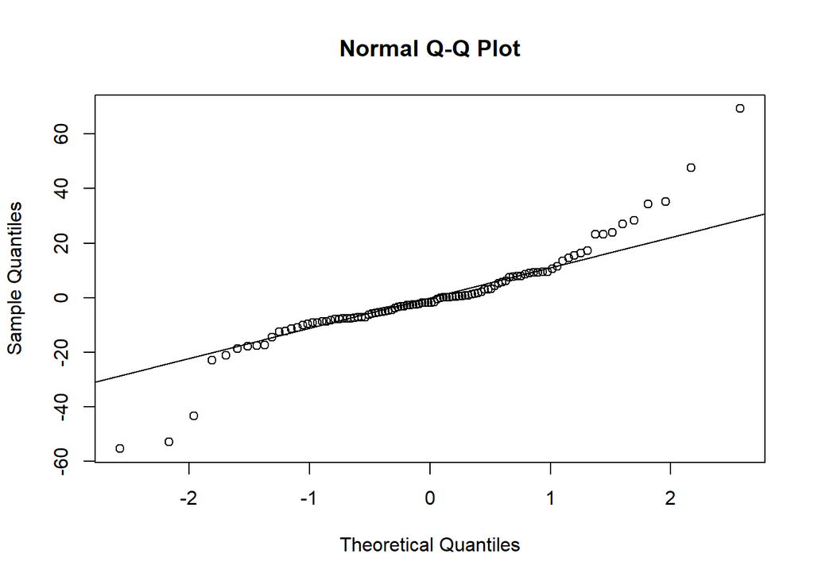

```r
# Q-Q plot of residuals
qqnorm(residuals(model4))
qqline(residuals(model4))
```

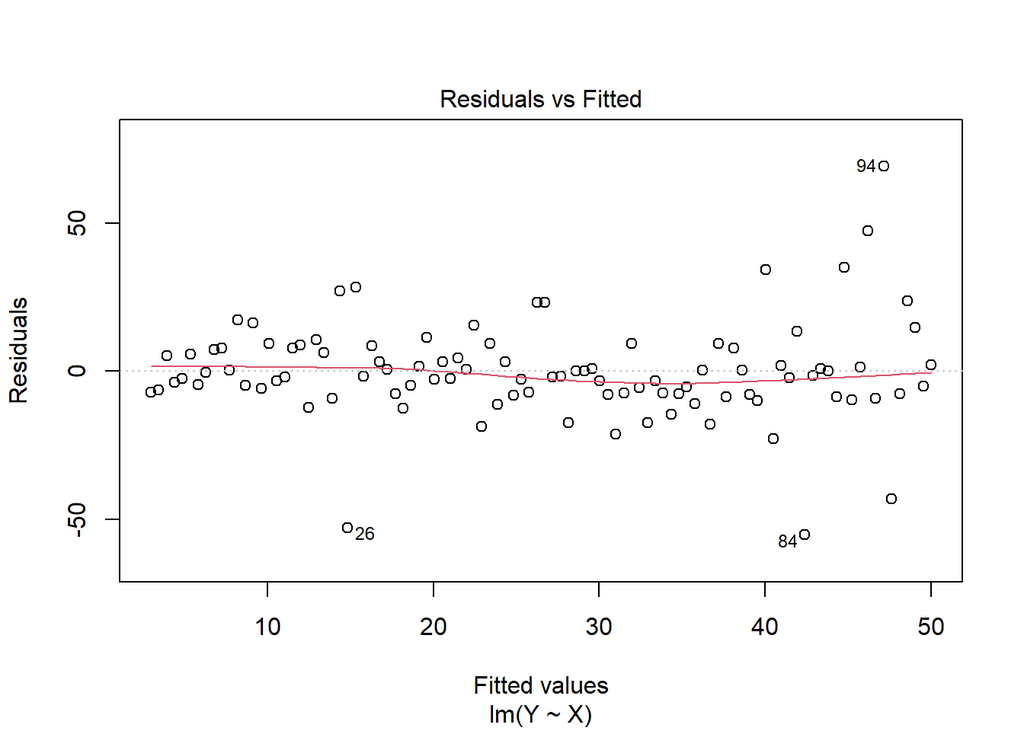

```r
# Residual plot
plot(model4, which = 1)
```

```r
# R-squared
summary(model4)$r.squared
```

```
## [1] 0.4089528
```

**Answer:** The scatterplot still shows a positive linear relationship, but some observations may deviate substantially from the regression line. In the Q-Q plot, the points in the lower tail fall below the reference line, while those in the upper tail rise above it. This suggests heavier tails than a normal distribution and indicates that the normality assumption may be violated.

### Question 3.2

Repeat the above analysis (including resetting the seed to 1), but change the distribution of the errors to exp(1/5). How does the shape of the Q-Q plot differ from that of a Q-Q plot with errors that follow a t-distribution?

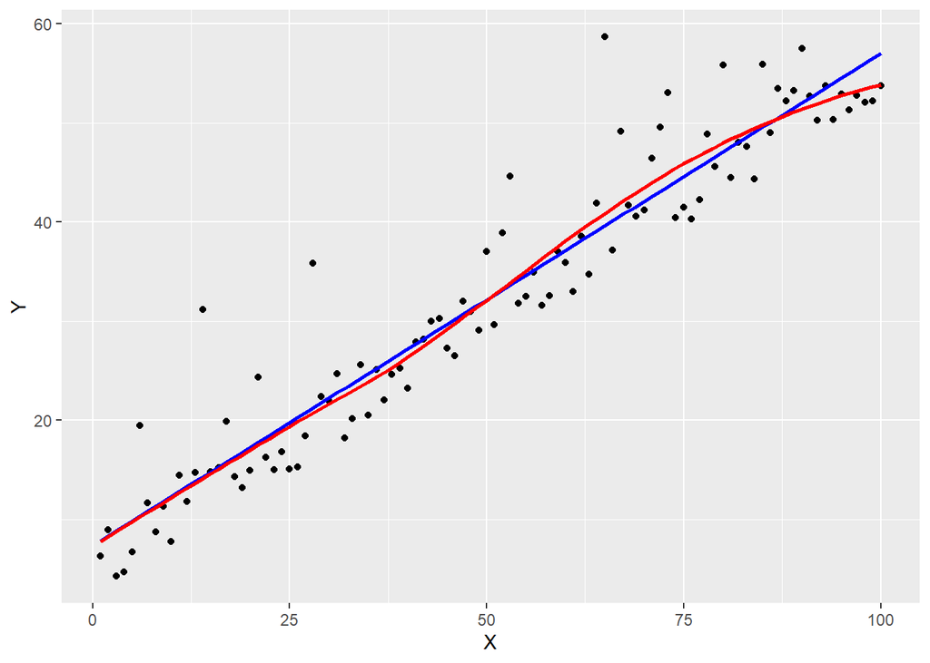

```r
# Set seed
set.seed(1)

# Create X values
X <- 1:100

# Generate exponential errors
error5 <- rexp(100, rate = 1/5)

# Generate Y values
Y5 <- 2 + 0.5 * X + error5

# Create data frame
data5 <- data.frame(X, Y = Y5)

# Fit SLR model
model5 <- lm(Y ~ X, data = data5)

# Scatterplot with regression line and LOESS curve
ggplot(data = data5, aes(x = X, y = Y)) +
  geom_point() +
  geom_smooth(method = "lm", se = FALSE, color = "blue") +
  geom_smooth(method = "loess", se = FALSE, color = "red")
```

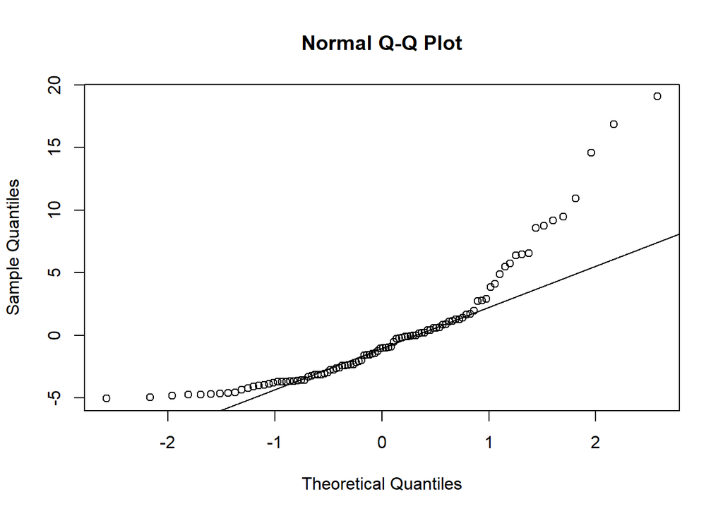

```r
# Q-Q plot
qqnorm(residuals(model5))
qqline(residuals(model5))
```

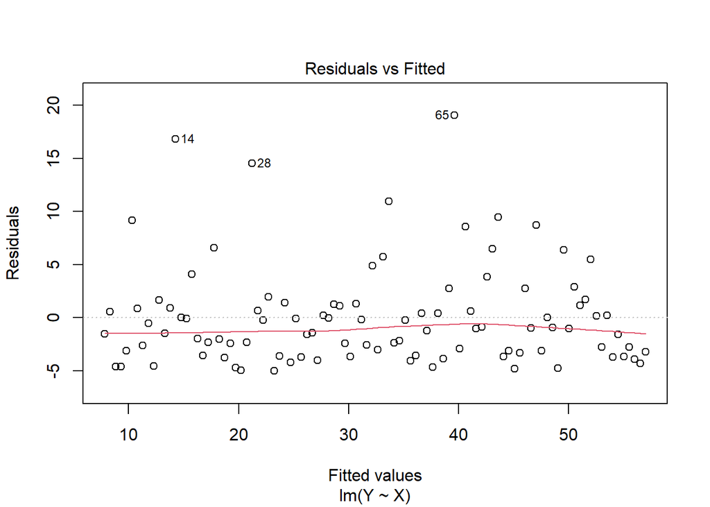

```r
# Residual plot
plot(model5, which = 1)
```

```r
# R-squared
summary(model5)$r.squared
```

```
## [1] 0.9044698
```

**Answer:** Unlike the t-distribution, which shows deviations in opposite directions at the two tails, the exponential distribution produces a curved Q-Q plot due to right-skewness. The lower tail lies above the reference line, while the upper tail deviates substantially upward. This indicates that the residuals are not normally distributed.

## Question 4

Now, let’s create an example where the regression function is correct but the assumption about the error term isn’t. Change the distribution of the error term to X * N(0, 1). Thus, the level of noise should increase as X increases. Does the scatterplot look like a fan? What does the residual plot show? Why isn’t the Q-Q plot perfectly consistent with a normal distribution?

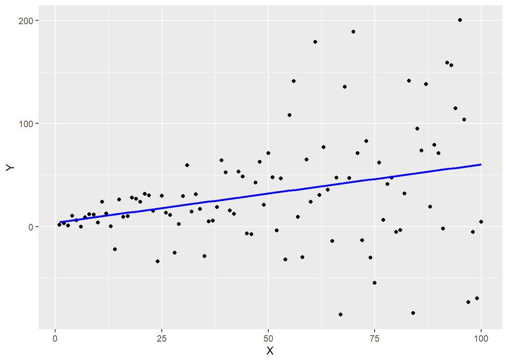

```r
# Set seed
set.seed(1)

# Create X values
X <- 1:100

# Generate errors with increasing variance
error6 <- X * rnorm(100, mean = 0, sd = 1)

# Generate Y values
Y6 <- 2 + 0.5 * X + error6

# Create data frame
data6 <- data.frame(X, Y = Y6)

# Fit SLR model
model6 <- lm(Y ~ X, data = data6)

# Scatterplot with regression line
ggplot(data = data6, aes(x = X, y = Y)) +
  geom_point() +
  geom_smooth(method = "lm", se = FALSE, color = "blue")
```

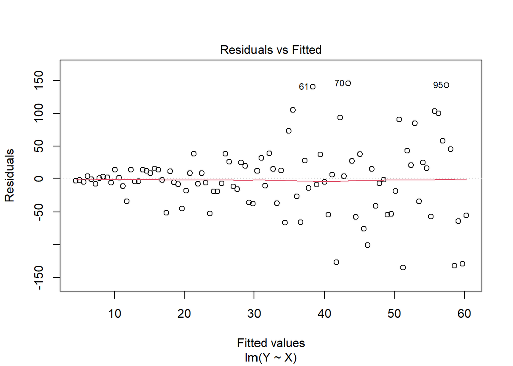

```r
# Residual plot
plot(model6, which = 1)
```

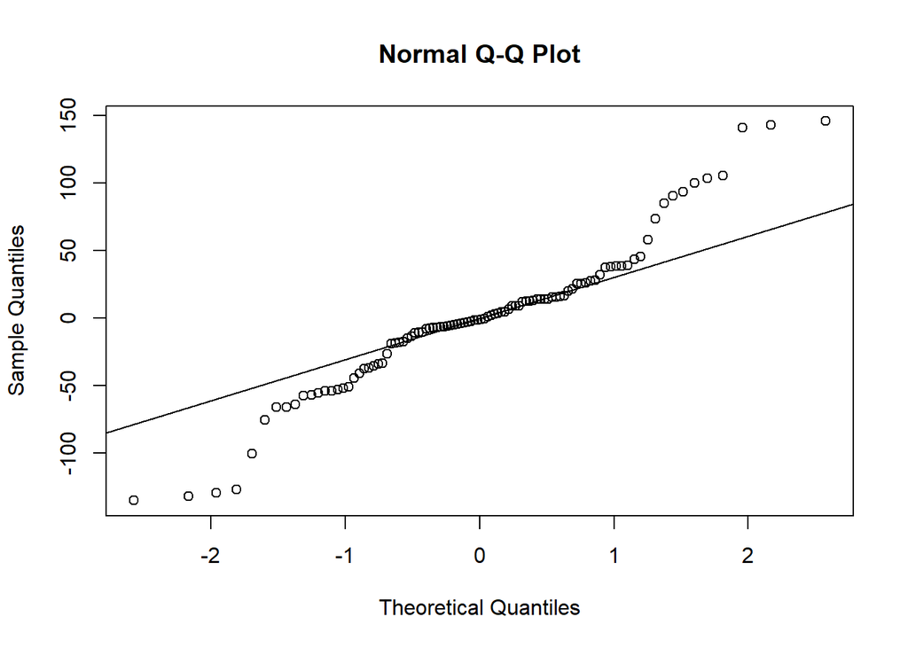

```r
# Q-Q plot
qqnorm(residuals(model6))
qqline(residuals(model6))
```

**Answer:** The scatterplot shows a fan-shaped pattern, with the spread of observations increasing as X increases. The residual plot also shows increasing variability across fitted values, indicating heteroscedasticity. Although the errors are normally distributed at each value of X, their variances increase with X. Therefore, the combined distribution of residuals does not follow a single normal distribution, which explains the deviations from the reference line in the Q-Q plot.

## Question 5

### Question 5.1

Return to the N(0,15) case, and set Y* = Y². So, we know by construction that a square root transformation will be ideal, although that might or might not be apparent from the data. What do the various plots show?

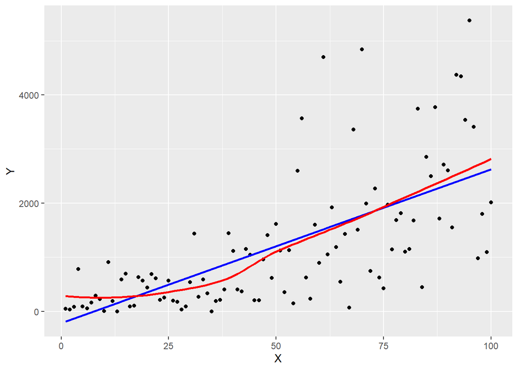

```r
# Set seed
set.seed(1)

# Create X values
X <- 1:100

# Generate errors with SD = 15
error7 <- rnorm(100, mean = 0, sd = 15)

# Generate Y and transformed Y
Y7 <- 2 + 0.5 * X + error7
Ystar <- Y7^2

# Create data frame
data7 <- data.frame(X, Y = Ystar)

# Fit SLR model
model7 <- lm(Y ~ X, data = data7)

# Scatterplot with regression line and LOESS curve
ggplot(data = data7, aes(x = X, y = Y)) +
  geom_point() +
  geom_smooth(method = "lm", se = FALSE, color = "blue") +
  geom_smooth(method = "loess", se = FALSE, color = "red")
```

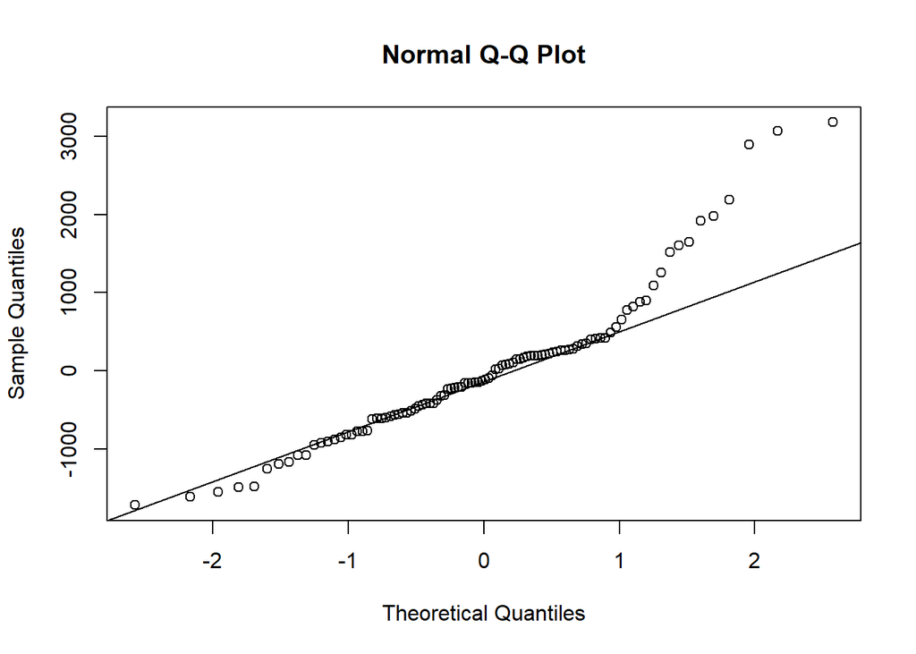

```r
# Q-Q plot
qqnorm(residuals(model7))
qqline(residuals(model7))
```

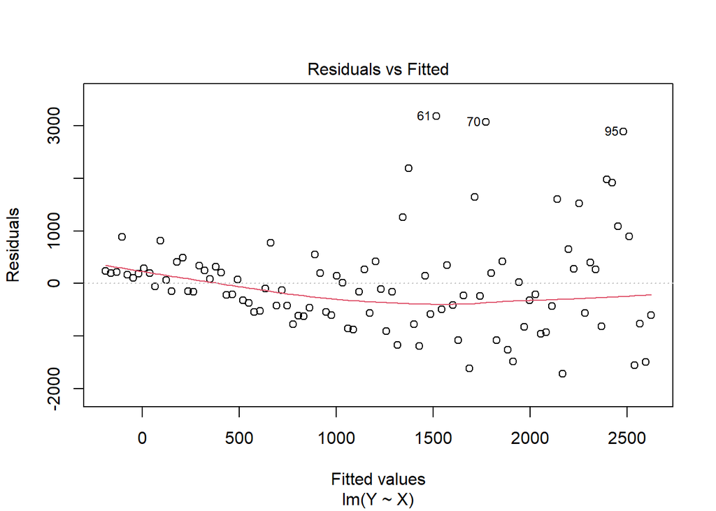

```r
# Residual plot
plot(model7, which = 1)
```

```r
# R-squared
summary(model7)$r.squared
```

```
## [1] 0.433467
```

**Answer:** The scatterplot suggests a nonlinear relationship, as the LOESS curve deviates from the fitted straight line. The residual plot shows increasing variability and a curved pattern, suggesting violations of the constant variance and linearity assumptions. The Q-Q plot also shows substantial deviations from normality, particularly in the upper tail. The R-squared is 0.4335.

Squaring the outcome introduces a nonlinear relationship and increasing variability as X increases. A square root transformation of Y* may help restore a more linear relationship and improve the model assumptions. However, because the original Y can be negative, taking the square root of Y* produces |Y| rather than the original Y.

### Question 5.2

Now, let’s create an example where the error term is correct but the regression function isn’t. Keep the N(0,15) error, but change the regression function to Y = 0.1 * (X - 50)^2. The issue should be clear from simply looking at the scatterplot, but go ahead and apply a loess fit and append a best-fitting straight line. What do the various plots show? Using this information, how might you move forward fitting the data?

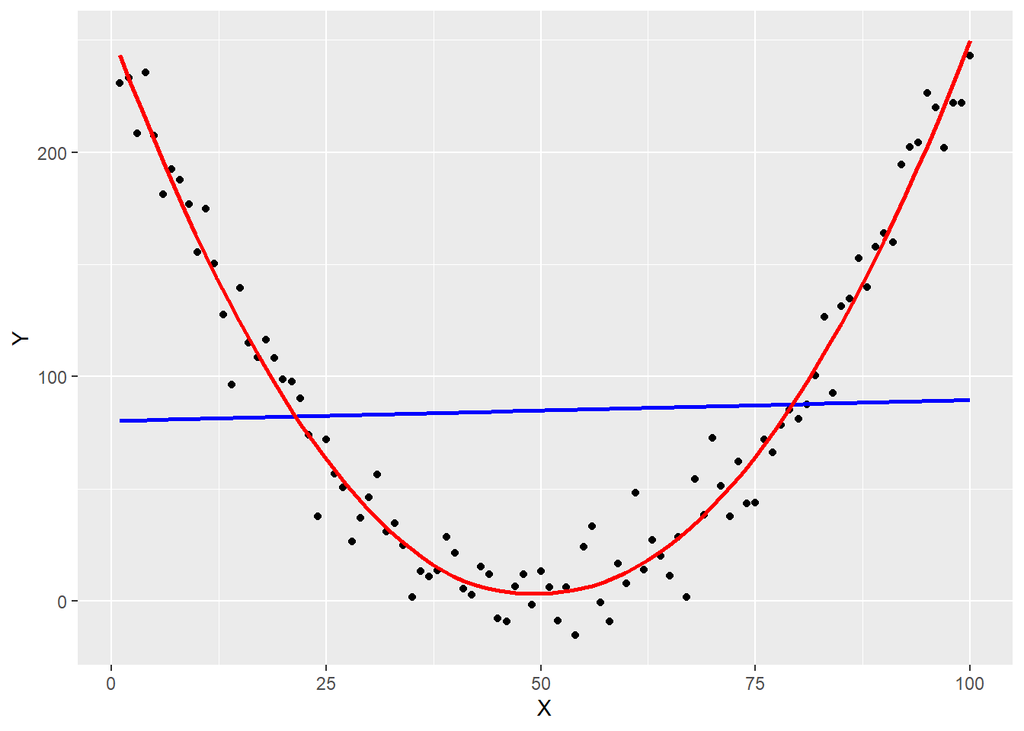

```r
# Set seed
set.seed(1)

# Create X values
X <- 1:100

# Generate normal errors
error8 <- rnorm(100, mean = 0, sd = 15)

# Generate Y using a quadratic function
Y8 <- 0.1 * (X - 50)^2 + error8

# Create data frame
data8 <- data.frame(X, Y = Y8)

# Fit a simple linear regression model
model8 <- lm(Y ~ X, data = data8)

# Scatterplot with linear regression and LOESS
ggplot(data = data8, aes(x = X, y = Y)) +
  geom_point() +
  geom_smooth(method = "lm", se = FALSE, color = "blue") +
  geom_smooth(method = "loess", se = FALSE, color = "red")
```

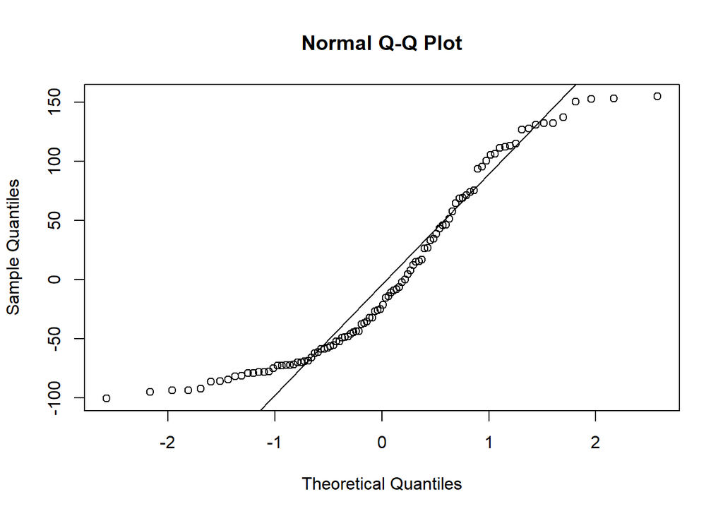

```r
# Q-Q plot
qqnorm(residuals(model8))
qqline(residuals(model8))
```

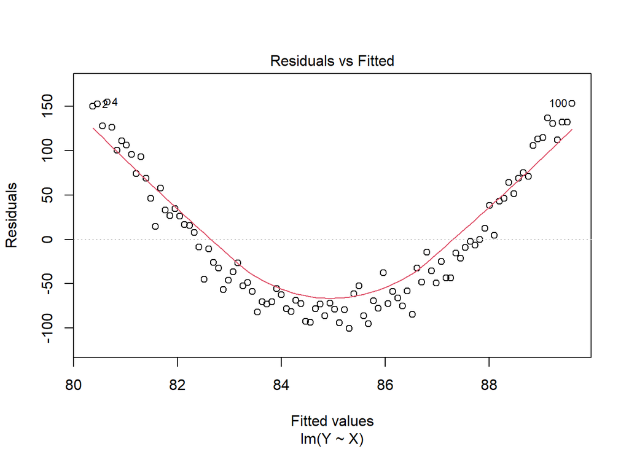

```r
# Residual plot
plot(model8, which = 1)
```

```r
# R-squared
summary(model8)$r.squared
```

```
## [1] 0.001274212
```

**Answer:** The scatterplot shows a clear U-shaped relationship between X and Y. The LOESS curve follows this pattern much better than the fitted straight line, indicating that a simple linear regression model is not appropriate. The residual plot shows a systematic pattern rather than random scatter, suggesting a violation of the linearity assumption. The Q-Q plot also deviates substantially from the reference line, even though the true errors were generated from a normal distribution. This occurs because the fitted linear model fails to capture the underlying quadratic relationship.

To better model the data, I would fit a quadratic regression model that includes both X and X². After fitting the new model, I would examine the residual and Q-Q plots to assess whether the model assumptions are better satisfied.